# NBA Salaries

Jeremy Hansen

1/15/2021

## Getting Started

I found a very helpful [guide](https://statisticaloddsandends.wordpress.com/2020/08/29/nba-salaries/) to play around with NBA salary data. The charts that I have made are only going to deal with the data from 2000-2017.

The first thing to do is load all the packages that we will use. I used tidyverse, plyr, dplyr, utils, ggplot2, ggthemes, readxl, and plotly. The important thing here is that you load plyr before dplyr, otherwise you will run into problems later.

The data is downloaded from [here](https://data.world/datadavis/nba-salaries).

```r
players <- read_csv("players.csv") %>%
  select(`_id`, name)
salaries <- read_csv("salaries_1985to2018.csv") %>%
  inner_join(players, by = c("player_id" = "_id"))
```

## Some data manipulation and basic chart

Now that the data is here, lets take a look at it.

```r
head(salaries)
```

```
## # A tibble: 6 x 8
##   league player_id  salary season season_end season_start team        name
##   <chr>  <chr>       <dbl> <chr>       <dbl>        <dbl> <chr>       <chr>
## 1 NBA    abdelal01  395000 1990-…       1991         1990 Portland T… Alaa Abde…
## 2 NBA    abdelal01  494000 1991-…       1992         1991 Portland T… Alaa Abde…
## 3 NBA    abdelal01  500000 1992-…       1993         1992 Boston Cel… Alaa Abde…
## 4 NBA    abdelal01  805000 1993-…       1994         1993 Boston Cel… Alaa Abde…
## 5 NBA    abdelal01  650000 1994-…       1995         1994 Sacramento… Alaa Abde…
## 6 NBA    abdulka01 1530000 1984-…       1985         1984 Los Angele… Kareem Ab…
```

Because I am only interested in 2000-2017, and only some of the columns, we’ll handpick the ones that matter. I chose to multiply total salary by .000000001, in order to make the scale be in billions.

```r
salaries1 <- salaries %>%
  filter(season_start >= 2000) %>%
  select(player_id, name, salary, year = season_start, team)

# total salary by year
yearly <- salaries1 %>%
  group_by(year) %>%
  dplyr::summarise(tot_salary = sum(salary) * .000000001)
```

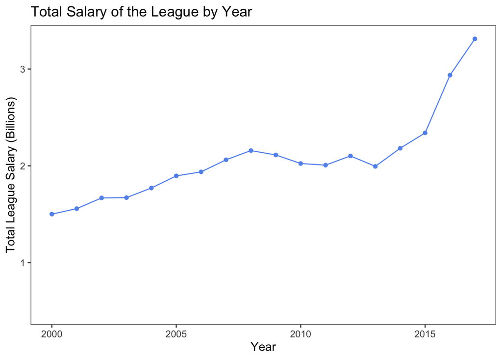

```r
#just a rough graph
ggplot(yearly, aes(x = year, y = tot_salary)) +
  geom_point(color = "cornflowerblue") +
  geom_line(color = "cornflowerblue") +
  expand_limits(y = .5) +
  labs(x = "Year",
       y = "Total League Salary (Billions)",
       title = "Total Salary of the League by Year") +
  theme_few()
```

We see that the total salary has been increasing each year, except from about 2009-2014. More recently, the amount of salary has been increasing more exponentially. This brought up a question: How has the increase in total salary compared to yearly inflation rate?

```r
rates <- c(1.2, 1.8, 2.4, 2.1, 1.3, 0.1, 1.6, 1.5, 2.1, 3.2, 1.6, -0.4, 3.8, 2.8, 3.2, 3.4, 2.7, 2.3, 1.6, 2.8, 3.4)
```